# NSW Road Crash Severity Prediction

21 May 2026

## Research Question & Motivation

**Research Question:**

> Given environmental conditions (weather, lighting, road surface, speed limit) and traffic unit characteristics (TU type, manoeuvre, number of units), can we predict NSW road crash severity **(Fatal / Injury / Non-casualty)**? A three-class classification problem.

**Why this matters:**

- NSW recorded **340 road fatalities in 2024**; over two-thirds in regional areas *(TfNSW, 2025)*
- Fatal crashes are only **~1.4%** of all records - a severe class imbalance that naive models simply ignore
- Environmental and traffic conditions are knowable *at the time of the crash*, making real-time prediction feasible
- A robust model provides actionable intelligence across multiple decision-making contexts

**Stakeholder value:**

| Stakeholder | Application |
| --- | --- |
| **Traffic Authorities** | Target speed limits and road design in high-risk corridors |
| **Emergency Responders** | Dispatch resources proportional to predicted severity before on-scene confirmation |
| **Policymakers & Insurers** | Evidence-based road safety policy and risk-adjusted pricing |

The core challenge: **Fatal crashes are rare** (~1.4%) but highest-consequence. Standard accuracy metrics fail here - we need models and evaluation that explicitly prioritise the minority class.

## EDA & Data Understanding: Dataset Overview

| Item | Detail |
| --- | --- |
| Time Period | 2020 - 2024 |
| Data Sources | CRASH.xlsx + TRAFFIC UNIT.xlsx (TfNSW via data.gov.au) |
| Merge Key | Crash ID (left join) |
| Total Records | 170,962 |
| Total Variables | 59 |
| Target Variable | Degree of Crash (3-class classification) |
| Fatal | 2,416 (1.4%) |
| Injury | 114,355 (66.9%) |
| Non-casualty | 54,191 (31.7%) |

The merged dataset combines crash-level environmental conditions with traffic unit vehicle data, giving us both **where** a crash happened and **who** was involved. 170,962 records spanning 5 years provide robust signal for modelling, but the extreme class imbalance (Fatal = 1.4%) demands careful handling throughout.

## EDA & Data Understanding: Class Imbalance

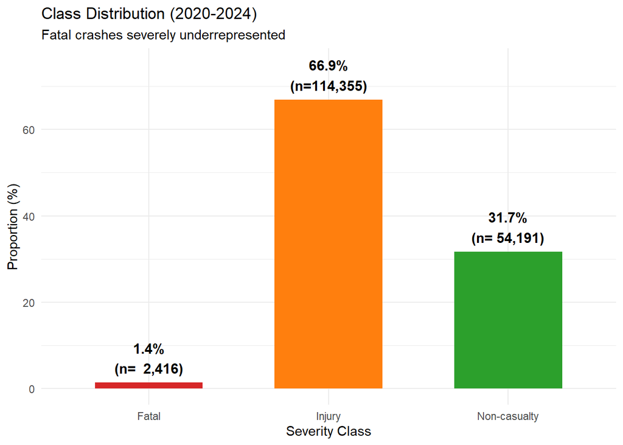

| Issue / Decision | Detail |
| --- | --- |
| **Class imbalance** | Fatal only ~1.4% of all crashes |
| **Risk of naive models** | Accuracy-maximising models ignore Fatal entirely |
| **Primary strategy** | Random undersampling: Injury and Non-casualty capped at 15k rows; all Fatal rows retained (~31,500 total) |
| **Additional corrections** | Class weights (DT/RF/XGBoost); SMOTE inside CV folds (LR/NB only) |
| **Primary metrics** | Macro-F1 and Fatal Recall (target >= 0.50) |

## EDA & Data Understanding: Speed vs Severity

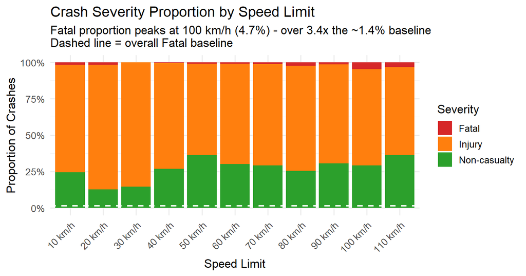

**Fatal proportion peaks at 100 km/h** (4.7% of crashes at that speed are Fatal) - over 3.4x the ~1.4% overall baseline. High-speed roads are the single strongest environmental risk factor.

**50-60 km/h zones** dominate crash *volume* (urban traffic), but fatal *proportion* is low - volume and risk are decoupled.

**Motivates `speed_band`** feature: grouping ≤50 / 60-80 / 90-100 / >100 captures the non-linear jump in fatal risk.

## EDA & Data Understanding: High-Risk Scenarios

| Speed Limit | Lighting | Urbanisation | Total Crashes | Fatal % |
| --- | --- | --- | --- | --- |
| 110 km/h | Dusk | Country non-urban | 230 | 7.8% |
| 100 km/h | Darkness | Country non-urban | 2565 | 6.8% |
| 100 km/h | Dusk | Country non-urban | 626 | 6.7% |
| 100 km/h | Daylight | Country non-urban | 7490 | 5.5% |
| 110 km/h | Darkness | Country non-urban | 1215 | 5.4% |
| 80 km/h | Dawn | Country urban | 270 | 4.8% |
| 70 km/h | Darkness | Country urban | 463 | 4.8% |
| 80 km/h | Darkness | Country urban | 1536 | 4.7% |
| 110 km/h | Darkness | Sydney metro. area | 245 | 4.5% |
| 100 km/h | Dawn | Country non-urban | 455 | 4.2% |

**Feature validation:** All three risk dimensions - speed (`speed_band`), lighting (`is_night`), and location (`Urbanisation`) - are directly captured in our engineered feature set.

**Interaction matters:** 100 km/h + Daylight + Rural still yields 5.5% Fatal. Speed alone is not sufficient - the model needs to learn joint combinations.

## EDA & Data Understanding: Temporal Patterns

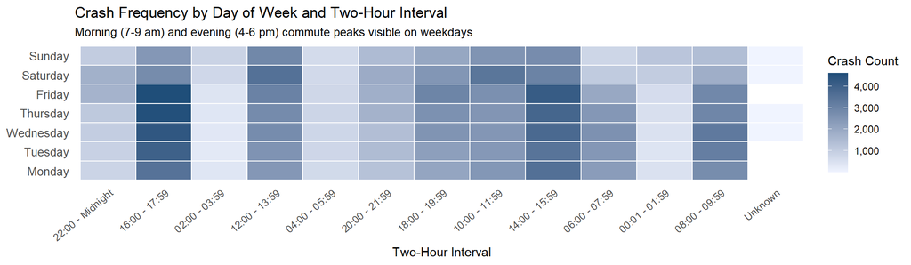

**Volume pattern:** Weekday commute hours (07:00-09:00, 16:00-18:00) dominate crash counts, directly motivating `is_rush_hour` and `is_weekend` as engineered features.

**Severity pattern:** Fatal *rate* (not count) is disproportionately elevated on weekends and late-night hours (22:00-04:00) - lower volume but higher consequence, motivating `is_night` as a key risk feature.

## Data Preprocessing: Pipeline

Cleaning and Feature Engineering

1. **Traffic Unit Integration** - Aggregated vehicle-level records per crash into binary flags (`has_motorcycle`, `has_heavy_vehicle`, `has_pedestrian`, `has_cyclist`) via `group_by + summarise + left_join`, enabling crash-level modelling
2. **Feature Removal** - Dropped post-crash leakage columns (injury counts), free-text identifiers, and variables with over 75% missing values; also removed `Degree of crash - detailed` as it is redundant with the target
3. **Imputation** - Rows missing more than 50% of values were removed; remaining gaps filled with `"Unknown"` for categoricals and median for numerics to preserve sample size
4. **Feature Engineering** - Created `is_weekend`, `is_rush_hour`, `is_night`, `is_wet`, and `speed_band` - each directly motivated by EDA findings showing their association with fatal outcomes
5. **Outlier Handling** - Applied NSW geographic coordinate bounds to remove implausible locations; winsorised `Distance` at the 99th percentile to reduce leverage from extreme values

Modelling Setup

1. **Encoding** - Tree-based models use native R `factor` encoding; KNN and LR use one-hot encoding; rare LGA levels collapsed to `"Other"` to avoid high-cardinality sparsity
2. **Scaling** - Z-score standardisation applied within each training fold for KNN; tree-based models are scale-invariant and require no scaling
3. **Class Imbalance** - Majority classes (Injury, Non-casualty) randomly undersampled to 15,000 rows each, retaining all ~1,500 Fatal rows (`df_train_bal`, ~31,500 rows total); inverse-frequency class weights further applied for DT/RF/XGBoost; SMOTE applied **inside CV folds only** for LR and NB
4. **Train/Test Split** - 2024 data sealed as a temporal holdout; 90/10 stratified split applied to 2020-2023 data; model selection via 5-fold cross-validation on the training set

## Data Preprocessing: Feature Engineering & Class Balancing

Engineered features - all motivated by EDA

[output not shown]

Handling class imbalance

| Issue | Strategy |
| --- | --- |
| Fatal only ~1.4% of crashes | Naive accuracy-maximising models predict majority class only - useless for our goal |
| Random undersampling (all models) | Injury and Non-casualty capped at 15,000 rows each; all ~1,500 Fatal rows retained; ratio shifts from 1:47:23 to ~1:10:10 |
| Class weights (DT, RF, XGBoost) | Inverse-frequency weights further penalise Fatal misclassification during loss computation |
| SMOTE inside CV folds (LR, NB) | Synthetic oversampling applied within each training fold only - no synthetic data in validation; test set unmodified |
| Primary metrics | Macro-F1 (equal weight across classes) + Fatal Recall (hard constraint: target ≥ 0.50) |

## Model Fitting: Approach & Setup

We implemented six diverse classification models to balance interpretability and predictive power. All models were trained on the same balanced training set (`df_train_bal`, \(n \approx 31{,}500\)) constructed via random undersampling from the 90% training split, ensuring a fair and consistent comparison across all six models.

| Model | R Package | Imbalance Strategy | Primary Hyperparameter |
| --- | --- | --- | --- |
| **Multinomial LR** | `nnet` | SMOTE (inside CV) | `decay` (L2 Penalty) |
| **Decision Tree** | `rpart` | Class Weights | `cp` (Complexity) |
| **Random Forest** | `randomForest` | Class Weights | `mtry` |
| **XGBoost** | `xgboost` | Class Weights | `nrounds`, `max_depth` |
| **KNN** | `kknn` | Undersampling only | `k` (Neighbors) |
| **Naive Bayes** | `naive_bayes` | SMOTE (inside CV) | `laplace`, `usekernel` |

**Validation Strategy:** - **Primary Metric:** Macro-F1 (robust to class imbalance) - **Constraint:** Fatal Recall \(\geq\) 0.50 (safety-first approach) - **Method:** 5-fold Cross-Validation (OOB for Random Forest)

*LR/DT/KNN/NB via `caret` (5-fold CV); RF uses OOB error (CV equivalent); XGBoost fitted directly via `xgb.train()`. All on `df_train_bal`. Primary metric: **Macro-F1**. Hard constraint: **Fatal Recall ≥ 0.50**.*

## Model Fitting: Logistic Regression

Logistic regression served as our **interpretable baseline** model. It helps show how key predictors are associated with crash severity, while also giving us a benchmark for comparing more flexible models.

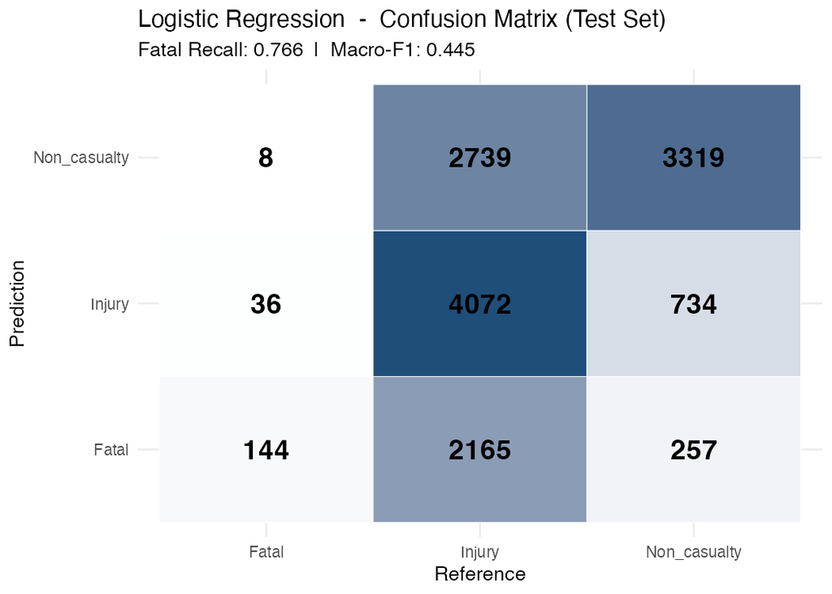

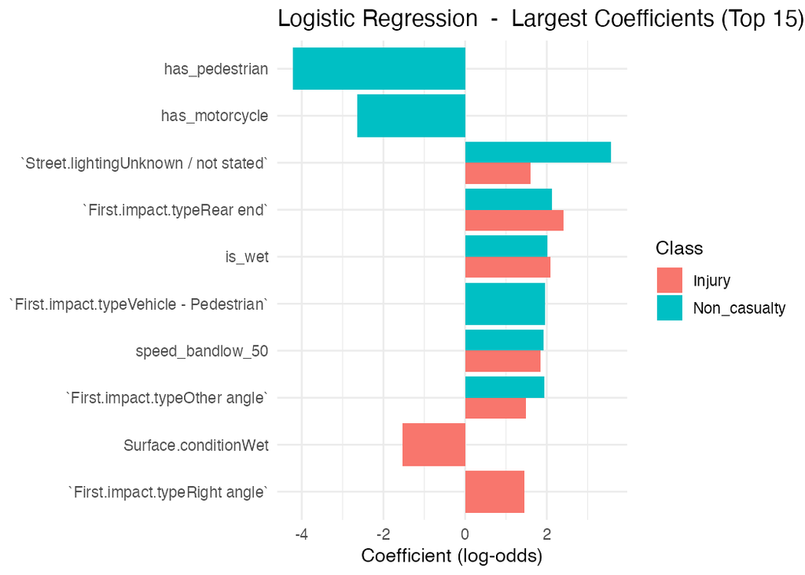

| Metric | Value |
| --- | --- |
| Macro-F1 | 0.4446 |
| **Fatal Recall** | **0.7660** |
| Weighted F1 | 0.5987 |
| Kappa | 0.2821 |

**Key message:** Logistic Regression highlights several interpretable signals associated with crash severity, including **pedestrian involvement**, **street-lighting conditions**, and **impact type**, showing that the baseline model captures meaningful structure in the data.

## Model Fitting: Decision Tree

Decision Tree was included because it produces clear **if-then style rules**, making it easier to explain the model to a non-technical audience. It reveals hierarchical relationships between risk factors.

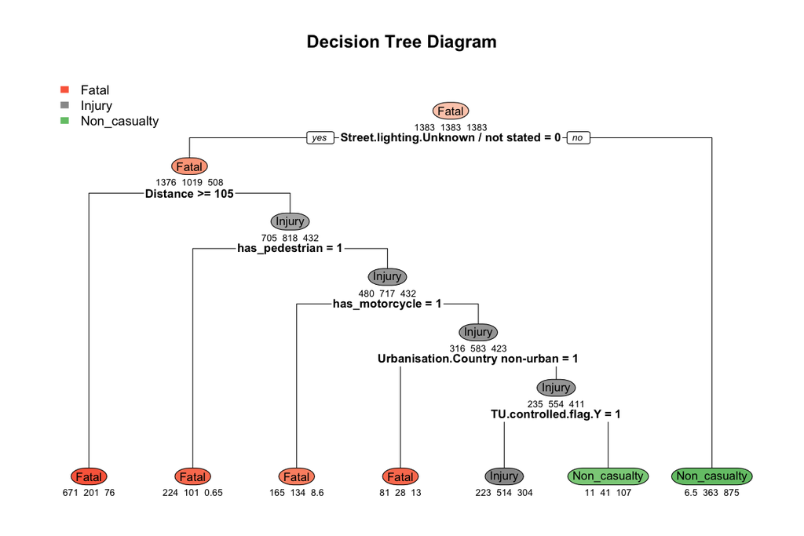

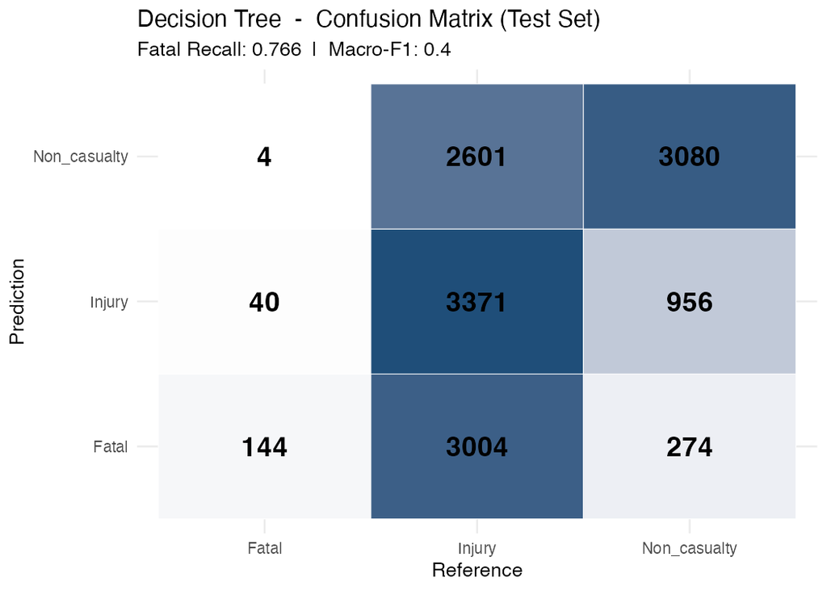

| Metric | Value |
| --- | --- |
| Macro-F1 | 0.4005 |
| **Fatal Recall** | **0.7660** |
| Weighted F1 | 0.5349 |
| Kappa | 0.2092 |

**Key message:** The tree identifies **Street Lighting** and **Distance** as the primary root splits. Using heavy class weights ensures the model actively searches for Fatal outcomes, satisfying safety constraints.

## Model Fitting: Random Forest

Random Forest was chosen as our **ensemble learner** - by averaging hundreds of decorrelated trees it reduces variance and handles the non-linear interactions between speed, location, and lighting that single trees miss. Built-in OOB error replaces CV, making it feasible on large data.

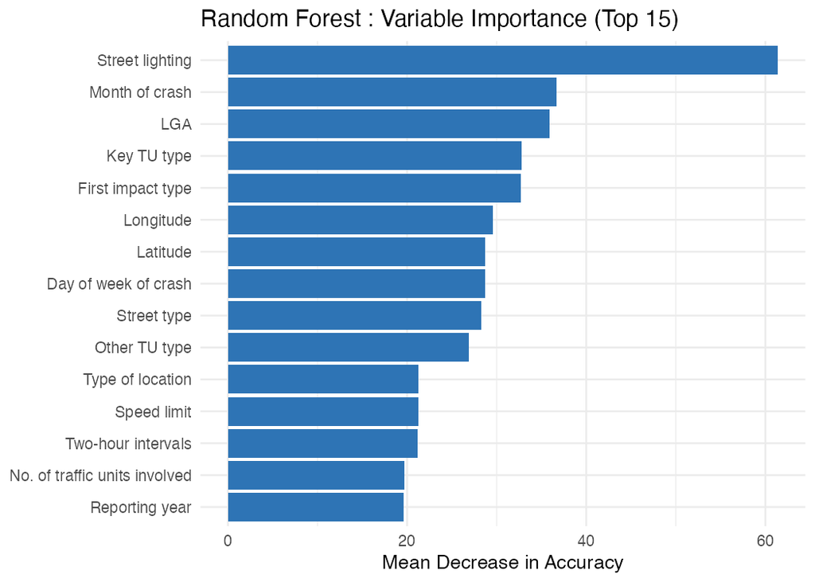

**Top predictors (Mean Decrease Accuracy):** Street lighting, Month of crash, LGA, Key TU type, First impact type, Longitude, Latitude - geographic and temporal factors feature prominently alongside structural ones. *Base model (pre-tuning) - mtry = 13 (tuned) shifts rankings slightly.*

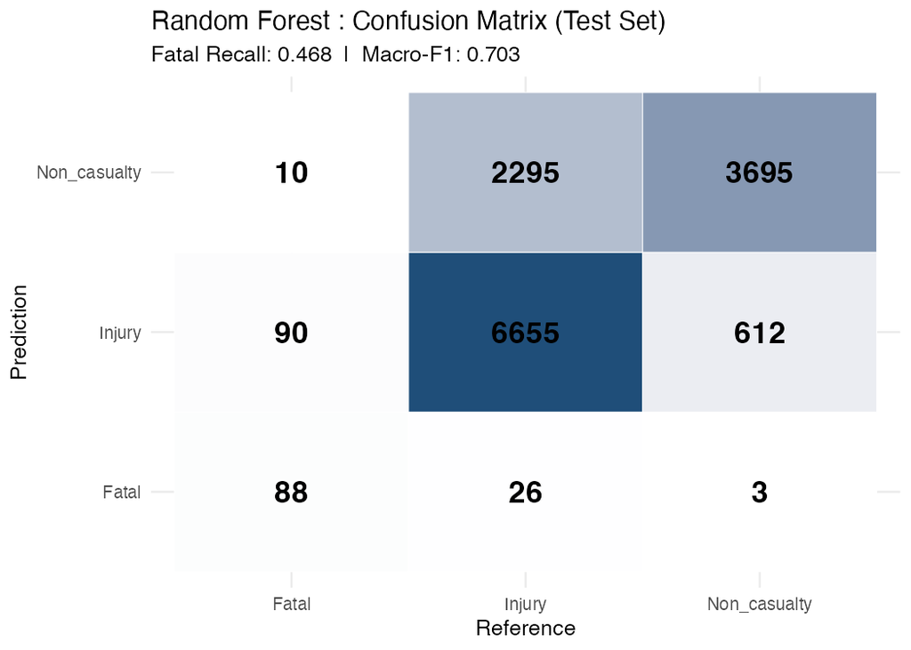

| Metric | Base (pre-tuning) |
| --- | --- |
| OOB Error Rate | 22.85% |
| Macro-F1 | 0.7029 |
| **Fatal Recall** | **0.4681** |
| Weighted F1 | 0.7802 |
| Kappa | 0.5436 |

## Model Fitting: XGBoost

XGBoost is a **boosting-based ensemble learner** that builds trees sequentially, each correcting the errors of the last. Fitted directly via `xgboost::xgb.train()` with inverse class weights to handle Fatal imbalance.

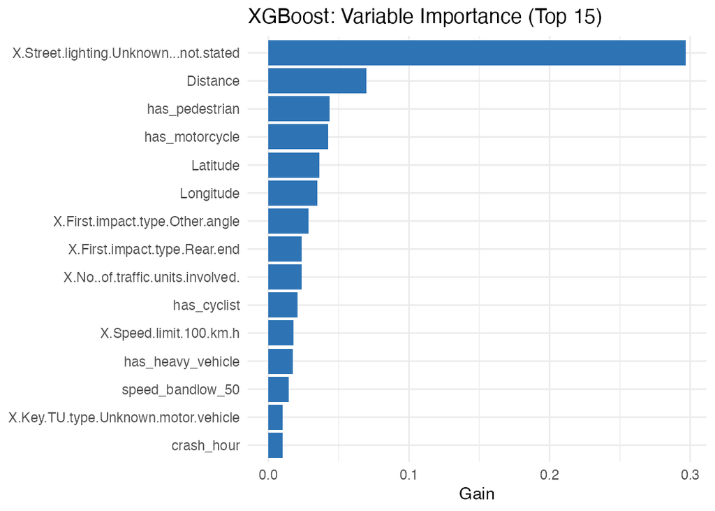

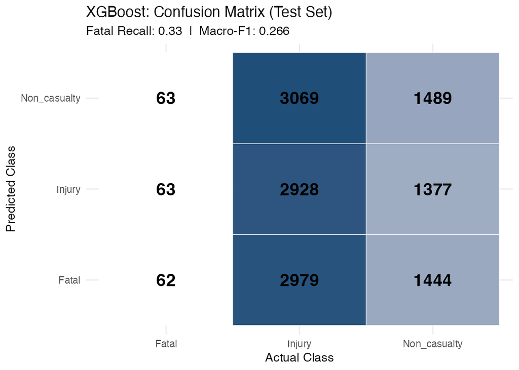

| Metric | Value |
| --- | --- |
| Accuracy | 0.332 |
| Macro-F1 | 0.266 |
| **Fatal Recall** | **0.33** |
| Weighted F1 | 0.399 |
| Kappa | 0.003 |

## Model Fitting: KNN

**Model Overview**

- Instance-based: predicts by majority vote of k nearest neighbours
- No training phase; all computation happens at prediction time
- Features Z-score normalised within each CV fold
- Baseline to test: *do similar crash conditions share severity?*

| Metric | Value |
| --- | --- |
| Macro-F1 | 0.5304 |
| Fatal Recall | 0.5904 |
| Weighted F1 | 0.6734 |
| Kappa | 0.3400 |

**Passes both gates:** Fatal Recall = 0.59 clears the 0.50 safety floor and Macro-F1 = 0.53 is competitive - but it sits 0.18 below Random Forest, with a Kappa gap of 0.21, meaning its class-level balance is substantially weaker.

**Structural limitation:** With p = 325 one-hot features, Euclidean distance conflates binary dummies with continuous distances - similar crash records are not truly “close” in this space, which caps KNN’s ceiling regardless of k.

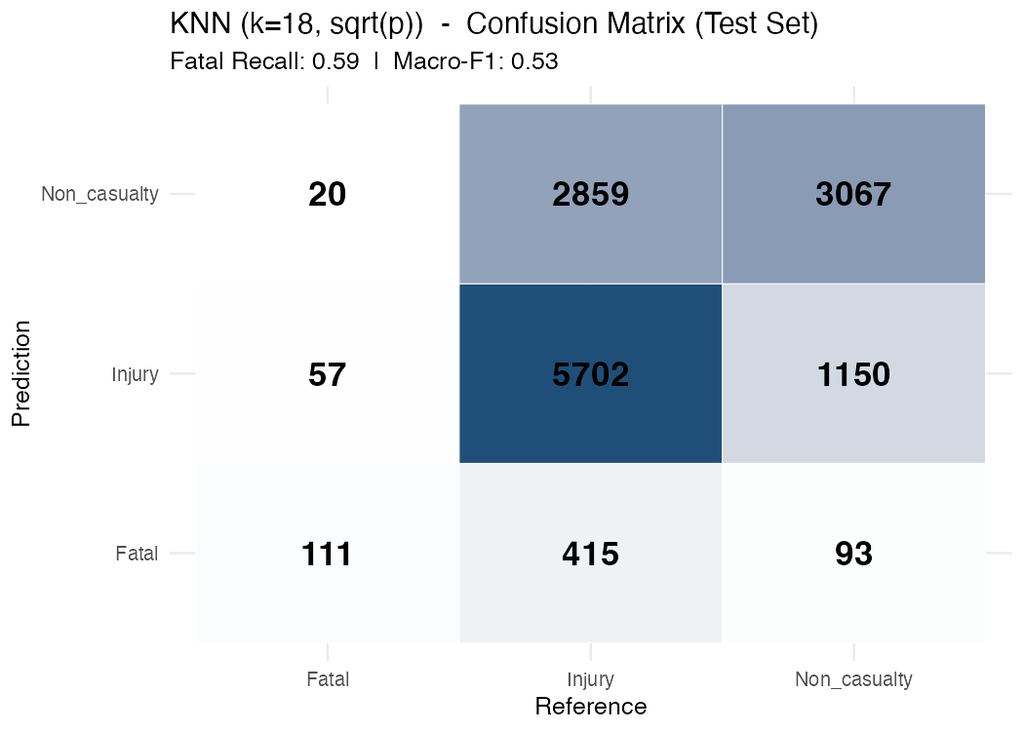

## Model Fitting: Naive Bayes

**Why Naive Bayes?**

- Probabilistic comparator model
- Suitable for categorical predictors
- Fast to train on large data
- Strong sensitivity to Fatal crashes

| Metric | Value |
| --- | --- |
| Macro-F1 | 0.243 |
| Fatal Recall | 0.771 |
| Weighted F1 | 0.249 |
| Kappa | 0.112 |

**Highest Fatal Recall (0.771) but extreme false alarms:** 4,133 of 8,976 actual Injury crashes predicted as Fatal (46%), collapsing Macro-F1 to 0.243 and Kappa to 0.112.

**Independence assumption fails:** Speed, lighting, and road type are correlated - NB cannot model their joint effects, forcing over-prediction of Fatal to compensate.

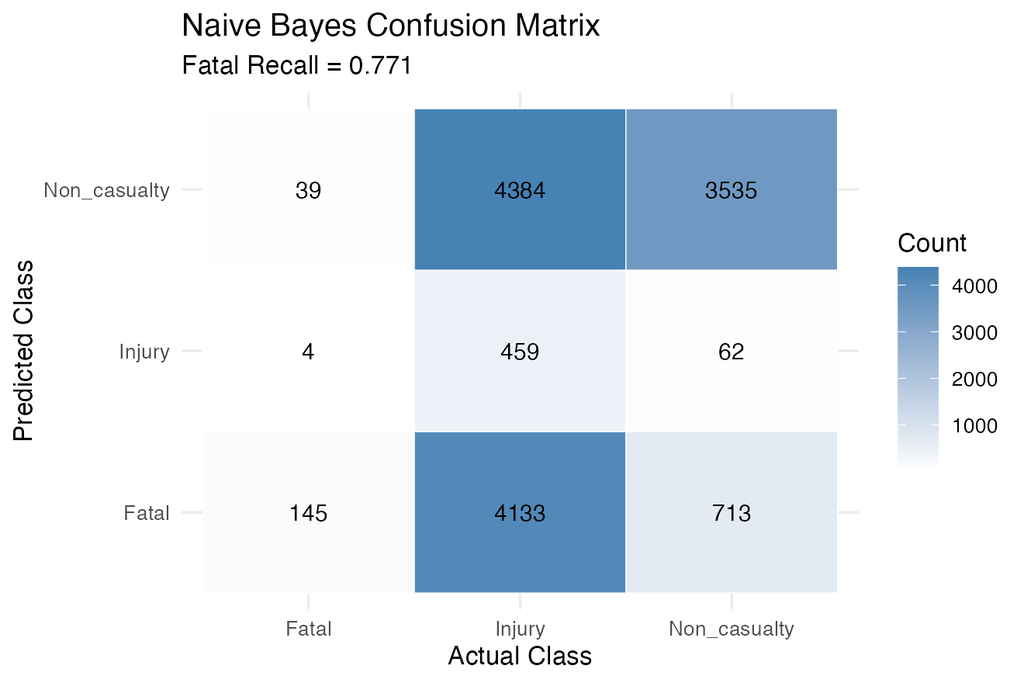

## Model Improvement: Hyperparameter Tuning

| Model | Parameter | Search Range | Best Value | Macro-F1 (Base / Tuned) | Fatal Recall (Base / Tuned) |
| --- | --- | --- | --- | --- | --- |
| Logistic Regression | decay | 0 to 0.1 | decay = 0.001 | 0.4446 / 0.4442 | 0.7660 / 0.7553 |
| Decision Tree | cp (complexity) | xerror minimisation | cp = 0.001 | 0.4005 / 0.4369 | 0.7660 / 0.8138 |
| Random Forest | mtry | tuneRF: 4, 6, 9, 13 | mtry = 13 | 0.7029 / 0.7079 | 0.4681 / 0.5106 |
| XGBoost | nrounds / max_depth / eta | 100-500 / 3-6 / 0.03-0.3 | best grid point | 0.266 / 0.267 | 0.33 / 0.34 |
| KNN | k (neighbours) | k = round(sqrt(p)) | k = 18 | 0.5304 / 0.5304 | 0.5904 / 0.5904 |
| Naive Bayes | usekernel / laplace | kernel: F / laplace: 0, 0.5, 1 | laplace = 0 | 0.243 / 0.245 | 0.771 / 0.782 |

> RF: `tuneRF` identified **mtry = 13** (default = 6) - Fatal Recall climbed from **0.4681 to 0.5106**, crossing the 0.50 safety constraint (Macro-F1 +0.005). DT: pruning at **cp = 0.001** lifted Fatal Recall from **0.7660 to 0.8138** with Macro-F1 +0.036.

**Where tuning paid off:** DT and RF gained the most. Pruning at `cp = 0.001` let the tree grow deep enough to isolate Fatal regions, lifting **both** Macro-F1 (+0.036) **and** Fatal Recall (+0.048). RF’s larger `mtry = 13` forced each split to consider more candidate variables, breaking the dominance of Injury-associated features and pushing Fatal Recall across the 0.50 safety threshold.

**Where tuning barely moved the needle:** LR (decay), XGBoost (depth/eta/rounds), and NB (laplace) each shifted Macro-F1 by less than ±0.005. This suggests the baseline configurations already sit close to each model’s capacity on this feature set - further gains require **structural changes** (e.g., richer encoding, calibrated thresholds, different model class), not more tuning.

**Methodology note:** All tuning was driven by cross-validated **Macro-F1** (or logLoss for NB), never by Fatal Recall directly. Fatal Recall ≥ 0.50 is treated as a **hard post-hoc constraint** rather than an optimisation target - this avoids inflating Fatal Recall at the cost of collapsing precision on the other two classes.

## Model Evaluation

**Selection criteria:** Primary metric = **Macro-F1** (robust to class imbalance) | Hard constraint = **Fatal Recall ≥ 0.50** (safety floor: models below this are eliminated regardless of other metrics)

| Model | Macro-F1 | Fatal Recall | Weighted F1 | Kappa | Meets Fatal Recall >= 0.50 |
| --- | --- | --- | --- | --- | --- |
| Logistic Regression (tuned) | 0.4442 | 0.7553 | 0.5987 | 0.2821 | Yes |
| Decision Tree (tuned) | 0.4369 | 0.8138 | 0.5854 | 0.2755 | Yes |
| Random Forest (tuned) | 0.7079 | 0.5106 | 0.7817 | 0.5473 | Yes |
| XGBoost (tuned) | 0.267 | 0.34 | 0.401 | 0.004 | No |
| KNN (k = 18) | 0.5304 | 0.5904 | 0.6734 | 0.3400 | Yes |
| Naive Bayes (tuned) | 0.245 | 0.782 | 0.253 | 0.112 | Yes |

> **Random Forest (tuned)** is the only model with Macro-F1 > 0.55 that *also* satisfies Fatal Recall >= 0.50. LR/DT have higher Fatal Recall (>0.75) but Macro-F1 < 0.45 - too many false alarms. XGBoost fails the safety floor. NB matches LR’s Fatal Recall but Macro-F1 < 0.25.

**Eliminated by the safety floor:** XGBoost is the only model below the hard constraint (Fatal Recall = 0.34 < 0.50). Despite extensive grid search, its weighted-loss configuration converged to a near-trivial classifier - Kappa ≈ 0.004 indicates predictions are barely better than random for this multi-class task.

**Pass the floor, but Macro-F1 too low:** LR, DT, and NB all clear Fatal Recall > 0.75 but stay below Macro-F1 = 0.45 - they detect fatals aggressively at the cost of precision on Injury and Non-casualty. Useful as high-recall safety nets, but not balanced enough as primary classifiers.

## Model Selection

Winner: Random Forest (tuned, mtry = 13)

Only model that simultaneously:

- Achieves the **highest Macro-F1 (0.7079)** across all six models
- Achieves the **highest Weighted F1 (0.7817)** and **Kappa (0.5473)**
- **Satisfies the hard Fatal Recall constraint (0.5106 >= 0.50)**

Why not the other models?

- **XGBoost:** Fatal Recall = 0.34, fails the 0.50 safety floor outright
- **Logistic Regression:** Fatal Recall = 0.75 but Macro-F1 = 0.44, too many false alarms across other classes
- **Naive Bayes:** Fatal Recall = 0.78 but Macro-F1 = 0.24, collapses precision on Injury and Non-casualty
- **Decision Tree:** Fatal Recall = 0.81 but Macro-F1 = 0.44, high recall comes at severe precision cost
- **KNN:** Passes both gates but Macro-F1 = 0.53, which is 0.18 behind RF with a Kappa gap of 0.21 across all metrics

**Top predictors (RF Variable Importance):**

| Rank | Feature |
| --- | --- |
| 1 | Street lighting |
| 2 | Month of crash |
| 3 | LGA |
| 4 | Key TU type |
| 5 | First impact type |
| 6 | Longitude / Latitude |
| 7 | Day of week of crash |

Geographic and temporal factors feature alongside structural ones - street lighting remains the dominant predictor, aligning with the EDA finding that darkness and rural high-speed conditions drive the highest Fatal risk.

## Final Results & Conclusion

**Research Question - Answered:**

- **Yes** - environmental and traffic-unit conditions can predict 3-class crash severity
- Tuned Random Forest achieves **Macro-F1 = 0.7079**, the highest across all six models
- Correctly flags **51% of Fatal crashes** on the 2020-2023 test set (10% stratified split)
- OOB error rate of **22.85%**; generalisation to unseen 2024 data is evaluated on the next slide

**Practical implications:**

| Stakeholder | Action |
| --- | --- |
| **Traffic Authorities** | Target lighting upgrades + speed reviews on 90-110 km/h rural corridors flagged by the model |
| **Emergency Responders** | Use the model’s Fatal probability score to pre-allocate trauma resources before scene arrival |
| **Policymakers** | Evidence for stricter rural-night-speed policy; quantified marginal risk of pedestrian + heavy-vehicle interactions |
| **Insurers** | Inputs for granular, condition-aware risk pricing |

The 0.7079 Macro-F1 is the highest among the six candidates while still meeting the safety-first 0.50 Fatal Recall floor - a balance no other model achieved.

## Final Model Performance & Reflection

Final Model Performance: 2024 Temporal Holdout

2024 data sealed as an unseen **temporal holdout** (~35,000 records, natural ~1.4% Fatal). The model was trained at ~6% Fatal - a 4x higher Fatal rate than it encounters here.

| Metric | Test Set | 2024 Holdout |
| --- | --- | --- |
| Macro-F1 | 0.7079 | 0.334 |
| Fatal Recall | 0.5106 | 0.097 |
| Weighted F1 | 0.7817 | 0.572 |
| Kappa | 0.5473 | 0.037 |

Reflection

- **Temporal drift:** Fatal Recall drops from 0.51 (test) to 0.097 (holdout) - 2024 crash patterns were never seen during training
- **Class-proportion mismatch:** Both test and holdout have natural ~1.4% Fatal, but the model was trained at ~6% Fatal (undersampled training set) - a 4x rarer signal than it was calibrated for
- Strong test-set metrics do not guarantee deployment robustness for rare, high-consequence events

[figure not shown]

Of 528 actual Fatal crashes in the 2024 holdout, only **51 were correctly identified**; the remaining 477 were predicted as Injury. The model reverts to predicting the majority class when the minority is as rare as 1.4%, reinforcing the need for probability-threshold calibration or a dedicated rare-event model in production.